# IS 362: Final Project Part 2 -- Analysis, Spatial Patterns, and Interactive Map

### Neighborhood Class, Transit Access, and COVID-19 Outcomes in New York City

**Student:** Daniel Foulen

**Class:** IS 362

**Date:** 5/11/2026

## Part 2

This notebook starts from `data/merged_modzcta.geojson`, the analysis-ready file built in Part 1. Part 1 handles data collection, cleaning, spatial joins, and export. Part 2 focuses on interpretation: income tiers, subway ridership, COVID death rates, subway access limits, spatial clustering, and the final interactive map.

Splitting the project into two notebooks keeps the workflow auditable. The first notebook explains how the dataset was built. This notebook explains what the dataset shows.

## Background

The pandemic did not hit a blank map. It hit a city already divided by income, housing, job type, and transit dependence. This project asks where those divisions showed up most clearly.

COVID-era harm in New York City was not evenly distributed. It clustered geographically, mapped onto income, and concentrated in neighborhoods whose residents had less ability to stop riding the subway. The pattern was structural and some of the conditions that produced it continue into 2026.

This notebook documents that pattern at the MODZCTA level, the finest geographic unit available in the public health data. It is descriptive, not causal. It examines where the burden fell, where it clustered, and what that geography implies for the people who designed and maintain the system.

## A Note on Positionality

I grew up in Queens. In late 2020, my family moved to Bushwick, a working class neighborhood in Brooklyn served by the J, M, Z, and L trains, so my siblings and I could more easily reach school and college. That move was as much a transit decision as a housing one.

In 2022, I worked a security job that required me to map my own commute by necessity: which lines, which hours, which stretches of the route were reliable enough to get me there on time and home safely. Later, a full-time data role in city agency operations took me between an outer borough location and offices near lower Manhattan. The difference in transit access between those two destinations was not subtle.

I did not come to this research question from outside it. The neighborhoods in this dataset are neighborhoods I have lived in, worked in, and depended on for transit, just as millions of other New Yorkers have.

These are the questions that proximity makes hard to ignore:

- [Why did the MTA suspend overnight service on the people who never stopped riding?](https://www.mta.info/document/24571)

  The cleaning rationale is documented. The impact is in the data. Those are two different questions.
- [If essential workers in working poor neighborhoods were the most consistent riders through the collapse, who are service decisions actually built around?](https://comptroller.nyc.gov/reports/beyond-rush-hour/)

  The farebox recovery logic assumes commuters return. What happens to the system when the people propping it up are never counted as the primary constituency?
- [What does it mean that the pocket of East New York with no subway stations assigned in this analysis, Spring Creek and Starrett City, the country's largest affordable housing complex, recorded the worst COVID outcome in the city?](https://pmc.ncbi.nlm.nih.gov/articles/PMC7799254/)

  That's not a data artifact. That's a policy outcome.
- [The J, L, and G are the lines with the most recurring disruptions right now.](https://abc7ny.com/post/train-service-disruptions-get-underway-subway-riders-brooklyn-queens/18987619/)

  Those lines run through Bushwick, East New York, and the neighborhoods this data identifies as having carried the highest burden in 2020. The question isn't whether that's a coincidence.

## Expected Patterns and Measurements

Before the analysis runs, this section names what we expect to see and defines the measurements used. Stating expectations in advance separates a hypothesis test from a post-hoc story fitted to results.

### Expected Patterns

If the central claim holds, the data should show:

- A gradient in COVID death rate from working poor to upper-middle class, consistent across the city
- Working poor and working class neighborhoods that kept riding through 2020 and rebounded less by 2022, because the option to stop riding was not available to their residents
- High-burden neighborhoods clustered spatially in the outer boroughs, not randomly distributed
- A weaker or harder-to-interpret pattern in neighborhoods defined by daytime work population rather than residential population, where the people who died are not necessarily the people the neighborhood houses

Three kinds of place carry strong public assumptions about what the pandemic looked like: working poor outer-borough neighborhoods where essential workers lived, upper-middle class Manhattan neighborhoods that shifted to remote work, and commercial cores where those two groups intersected during the workday but not at home. The analysis tests those assumptions against the data and returns to them in Step 10 with the results.

### What the Measurements Mean

**Income tier.** Neighborhoods grouped into three categories based on ACS 2021 median household income: working poor (under $50,000), working class ($50,000 to $100,000), and upper-middle class (above $100,000). These thresholds are fixed by design and reflect material differences in NYC cost of living. The choice of where to draw a threshold is not a neutral act.

**COVID death rate.** Cumulative confirmed COVID-19 deaths per 100,000 residents through 2022, reported at the MODZCTA level by NYC Health. This is a residential metric. Deaths are counted where people lived, not where they worked or rode the subway.

**2020 ridership volume.** Annual subway ridership at stations spatially assigned to each MODZCTA. Neighborhoods where station ridership held up through 2020 likely served riders who continued using the subway through the worst of the collapse. Neighborhoods where ridership dropped sharply likely include areas where more riders had alternatives, such as remote work, car access, or reduced travel.

**Ridership rebound (2020-2022).** Percent change in subway ridership from 2020 to 2022. This measures climb from the 2020 floor, not recovery to a pre-pandemic baseline.

**No assigned station.** 54 MODZCTAs received no subway station assignment under this project's spatial join. Residents of these neighborhoods use buses, ferries, or walking access to adjacent MODZCTAs. They remain in every non-ridership comparison.

**Queen contiguity.** Two neighborhoods are considered neighbors if their map polygons share any border or corner point. This is how the spatial analysis defines proximity.

**Moran's I.** A statistic that measures whether a variable is randomly distributed across space or clustered. A positive value means similar values tend to sit next to each other geographically. The p-value indicates whether the result is distinguishable from chance.

**LISA cluster types.** Local Indicators of Spatial Association. Each neighborhood is assigned one of five types based on its own value and the values of its neighbors, at p < 0.05.

| Type | Meaning |
| --- | --- |
| High-High | High death rate surrounded by high death rate neighborhoods. The burden is geographically concentrated. |
| Low-Low | Low death rate surrounded by low death rate neighborhoods. |
| High-Low | High death rate surrounded by lower-rate neighbors. A spatial outlier. |
| Low-High | Low death rate surrounded by higher-rate neighbors. Also an outlier. |
| Not Significant | No statistically meaningful spatial pattern at this location. |

## What This Notebook Produces

Starting from `data/merged_modzcta.geojson`, the analysis-ready file built in Part 1, this notebook produces:

| Output | Description |
| --- | --- |
| Summary statistics | Mean and median COVID death rate, ridership volume, rebound, and poverty rate by income tier |
| Chart 1 | 2020 subway ridership volume by income tier |
| Chart 2 | Ridership rebound 2020 to 2022, by income tier |
| Chart 3 | COVID death rate by income tier, bar and distribution |
| Chart 4 | Ridership volume versus COVID death rate, colored by income tier |
| Chart 5 | LISA cluster map, local spatial autocorrelation of COVID death rate |
| Chart 6 | COVID death rate by income tier and subway access |
| `map.html` | Interactive choropleth with income tier as primary color, subway lines and stations toggleable, LISA cluster type and full neighborhood data in popups |

## Step 1: Imports and Configuration

The following libraries are required for the analysis, spatial statistics, static charts, and interactive map output.

If running in a fresh environment, install them before executing this notebook:

```
pip install numpy pandas geopandas matplotlib folium libpysal esda mapclassify
```

| Library | Purpose |
| --- | --- |
| `numpy` | numerical operations |
| `pandas` | tabular data manipulation |
| `geopandas` | spatial data manipulation |
| `matplotlib` | static charts |
| `folium` | interactive Leaflet map output |
| `libpysal` | spatial weights matrix construction |
| `esda` | Moran's I and Local Moran's I / LISA |
| `mapclassify` | choropleth classification support |
| `pathlib` | file path handling |
| `warnings` | suppress non-critical display warnings |

This step also sets display options so intermediate tables are easier to inspect while the notebook runs.

```python
import geopandas as gpd
import pandas as pd
import numpy as np
import matplotlib.pyplot as plt
import matplotlib.patches as mpatches
import seaborn as sns
import folium
from folium.features import GeoJsonTooltip
from adjustText import adjust_text
import os

sns.set_style("whitegrid")
plt.rcParams["figure.dpi"] = 120

TIER_ORDER = ["working poor", "working class", "upper-middle class"]

# ── Color palette ─────────────────────────────────────────────────────────────
PALETTE = {
    "working poor":       "#FECDAA",   # Peach Glow
    "working class":      "#B2F7EF",   # Icy Aqua
    "upper-middle class": "#05668D",   # Baltic Blue
}

# LISA cluster colors (spatial statistics, separate from income tiers)
LISA_COLORS = {
    "High-High":       "#c0392b",   # high burden cluster
    "Low-Low":         "#2980b9",   # low burden cluster
    "High-Low":        "#e67e22",   # spatial outlier
    "Low-High":        "#8e44ad",   # spatial outlier
    "Not Significant": "#cccccc",
}

# MTA official line colors
LINE_COLORS = {
    "A": "#0039A6", "C": "#0039A6", "E": "#0039A6",
    "B": "#FF6319", "D": "#FF6319", "F": "#FF6319", "M": "#FF6319",
    "G": "#6CBE45",
    "J": "#996633", "Z": "#996633",
    "L": "#A7A9AC",
    "N": "#FCCC0A", "Q": "#FCCC0A", "R": "#FCCC0A", "W": "#FCCC0A",
    "1": "#EE352E", "2": "#EE352E", "3": "#EE352E",
    "4": "#00933C", "5": "#00933C", "6": "#00933C",
    "7": "#B933AD",
    "S": "#808183",
}

DATA_DIR    = "data"
MAP_PATH    = "map.html"
MERGED_PATH = os.path.join(DATA_DIR, "merged_modzcta.geojson")
```

## Step 2: Load Analysis-Ready MODZCTA File

This notebook starts where Part 1 ends.

Part 1 produces `data/merged_modzcta.geojson`, the analysis-ready file used throughout Part 2. It combines COVID outcomes, ACS income and poverty estimates, subway ridership summaries, station assignments, and MODZCTA boundaries into one neighborhood-level spatial dataset.

Loading this file first keeps Part 2 focused on analysis rather than repeating the data-building process. The notebook checks the file's shape, coordinate reference system, column names, and key fields before running any summaries, charts, spatial statistics, or maps.

The expected unit of analysis is MODZCTA. Neighborhood names are used for readability, but all joins, summaries, charts, and spatial statistics are based on MODZCTA codes.

```python
assert os.path.exists(MERGED_PATH), \
    f"FAIL  merged_modzcta.geojson not found at {MERGED_PATH}. Rerun Part 1."

gdf = gpd.read_file(MERGED_PATH)

assert len(gdf) >= 170, \
    f"FAIL  Expected at least 170 features, got {len(gdf)}."

print(f"PASS  merged_modzcta.geojson: {len(gdf)} features loaded.")
```

```
PASS  merged_modzcta.geojson: 177 features loaded.
```

## Step 3: Load and Orient

Before analyzing patterns, the dataset needs a basic audit.

This step checks whether the MODZCTA geography is behaving as expected, whether missing values are explainable, and whether the key comparison groups are large enough to interpret. Basic verifications.

The main checks are:

- MODZCTA codes should be valid and unique
- neighborhood names should be treated as readable labels, not unique keys
- missing subway fields should correspond to no-station neighborhoods
- income tiers and borough groups should have enough observations for comparison
- subway-served and no-station neighborhoods should be clearly separated before ridership analysis

## Step 3.1: Data Audit

Confirm MODZCTA codes are valid, neighborhood names are descriptive labels (not unique keys), and the only nulls are the expected 54 from no-station neighborhoods.

```python
valid_modzcta = gdf["MODZCTA"].astype(str).str.match(r"^\d{5}$")
assert valid_modzcta.all(), \
    f"FAIL  {(~valid_modzcta).sum()} invalid MODZCTA codes found."
print(f"PASS  All {len(gdf)} MODZCTAs are valid 5-digit codes.")

n_unique_names = gdf["NEIGHBORHOOD_NAME"].nunique()
print(f"PASS  {n_unique_names} distinct neighborhood names across "
      f"{len(gdf)} MODZCTAs: names are labels, not keys!")

analytical = ["ridership_2020", "pct_change_20_22",
              "COVID_DEATH_RATE", "median_income_wtd", "poverty_rate"]
nulls = gdf[analytical].isna().sum()
nulls = nulls[nulls > 0]
if len(nulls):
    display(nulls.rename("null count").to_frame())
else:
    print("PASS  No unexpected nulls in analytical columns.")

for col in analytical:
    n = (gdf[col] == 0).sum()
    if n:
        print(f"NOTE  {col}: {n} zero value(s). Verify if intentional.")

subway = gdf.dropna(subset=["ridership_2020"]).copy()
```

```
PASS  All 177 MODZCTAs are valid 5-digit codes.
PASS  162 distinct neighborhood names across 177 MODZCTAs: names are labels, not keys!
```

|  | null count |
| --- | --- |
| ridership_2020 | 54 |
| pct_change_20_22 | 54 |

### Variable Audit

```python
eda_cols = [
    "median_income_wtd",
    "poverty_rate",
    "COVID_DEATH_RATE",
    "ridership_2020",
    "pct_change_20_22",
]

display(
    gdf[eda_cols]
    .describe()
    .T
    .style.format("{:,.2f}")
)

missing_summary = (
    gdf[eda_cols]
    .isna()
    .sum()
    .rename("missing_count")
    .to_frame()
)
missing_summary["missing_pct"] = missing_summary["missing_count"] / len(gdf) * 100

display(missing_summary.style.format({
    "missing_pct": "{:.1f}%"
}))
```

|  | count | mean | std | min | 25% | 50% | 75% | max |
| --- | --- | --- | --- | --- | --- | --- | --- | --- |
| median_income_wtd | 177.00 | 85,769.66 | 40,481.31 | 21,846.00 | 59,032.00 | 77,378.00 | 101,409.00 | 250,001.00 |
| poverty_rate | 177.00 | 0.15 | 0.09 | 0.02 | 0.09 | 0.13 | 0.19 | 0.45 |
| COVID_DEATH_RATE | 177.00 | 528.01 | 231.33 | 11.42 | 395.71 | 515.68 | 654.52 | 1,612.62 |
| ridership_2020 | 123.00 | 5,230,169.44 | 4,806,436.61 | 165,962.00 | 2,375,560.00 | 4,059,727.00 | 6,576,053.00 | 33,755,218.00 |
| pct_change_20_22 | 123.00 | 0.50 | 0.25 | -0.23 | 0.29 | 0.48 | 0.67 | 1.48 |

|  | missing_count | missing_pct |
| --- | --- | --- |
| median_income_wtd | 0 | 0.0% |
| poverty_rate | 0 | 0.0% |
| COVID_DEATH_RATE | 0 | 0.0% |
| ridership_2020 | 54 | 30.5% |
| pct_change_20_22 | 54 | 30.5% |

This audit checks the variables used in the analysis before plotting and spatial modeling. The most important missingness issue is ridership: MODZCTAs without assigned subway stations do not have 2020 ridership or recovery values. Those neighborhoods remain in the COVID death-rate and LISA analysis, but they are excluded from subway-ridership plots.

## Step 3.2: Income Tier and Borough Overview

Three income tiers across 177 MODZCTAs and five boroughs. The tier counts are uneven: 29 working poor, 100 working class, 48 upper-middle class. Sample size matters for interpreting tier averages.

```python
tier_summary = gdf.groupby("income_tier").agg(
    n=("MODZCTA", "count"),
    income_min=("median_income_wtd", "min"),
    income_median=("median_income_wtd", "median"),
    income_max=("median_income_wtd", "max"),
).reindex(TIER_ORDER)

display(tier_summary.style.format({
    "income_min":    "${:,.0f}",
    "income_median": "${:,.0f}",
    "income_max":    "${:,.0f}",
}))

display(gdf.groupby("BOROUGH_GROUP")["MODZCTA"]
          .count().rename("neighborhoods").to_frame())
```

| income_tier | n | income_min | income_median | income_max |
| --- | --- | --- | --- | --- |
| working poor | 29 | $21,846 | $37,093 | $49,679 |
| working class | 100 | $50,164 | $73,440 | $99,924 |
| upper-middle class | 48 | $100,528 | $131,046 | $250,001 |

| BOROUGH_GROUP | neighborhoods |
| --- | --- |
| Bronx | 25 |
| Brooklyn | 37 |
| Manhattan | 44 |
| Queens | 59 |
| Staten Island | 12 |

## Step 4: Ridership by Income Tier

Did station ridership follow the income gradient we expected? Working poor and working class neighborhoods should show stronger 2020 ridership and weaker 2020-2022 rebound if their residents and nearby riders had less ability to stop using the subway.

## Step 4.1: 2020 Subway Volume

2020 ridership volume by income tier. Upper-middle class shows the highest mean, but this is Penn Station and Grand Central inflating the average rather than per-capita dependence. Median is the better comparison.

| income_tier | n | ridership_2020_mean | ridership_2020_median |
| --- | --- | --- | --- |
| working poor | 24 | 4,357,939 | 4,168,356 |
| working class | 69 | 3,611,939 | 2,948,473 |
| upper-middle class | 30 | 9,649,883 | 7,830,869 |

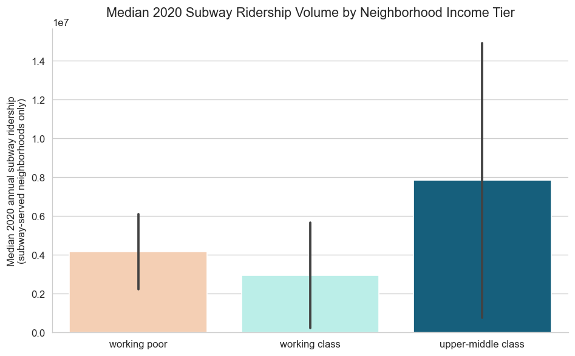

```python
# Summary table: subway-served only
retention = subway.groupby("income_tier").agg(
    n=("MODZCTA", "count"),
    ridership_2020_mean=("ridership_2020", "mean"),
    ridership_2020_median=("ridership_2020", "median"),
).reindex(TIER_ORDER)

display(retention.style.format({
    "ridership_2020_mean":   "{:,.0f}",
    "ridership_2020_median": "{:,.0f}",
}))

# Bar chart
fig, ax = plt.subplots(figsize=(8, 5))
sns.barplot(
    data=subway,
    x="income_tier",
    y="ridership_2020",
    order=TIER_ORDER,
    palette=PALETTE,
    hue="income_tier",
    legend=False,
    estimator="median",
    errorbar="sd",
    ax=ax,
)
ax.set_title("Median 2020 Subway Ridership Volume by Neighborhood Income Tier", fontsize=13, pad=12)
ax.set_ylabel("Median 2020 annual subway ridership\n(subway-served neighborhoods only)", fontsize=10)
ax.set_xlabel("")
ax.tick_params(axis="x", labelsize=10)
sns.despine()
plt.tight_layout()
plt.show()
```

Error bars show standard deviation, so they represent within-group variation rather than uncertainty around the mean.

## Step 4.2: Rebound 2020 to 2022

Rebound from the 2020 floor through 2022. The pattern inverts: upper-middle class rebounded most (74.5%) because they had the most room to rebound. Working poor rebounded least (28.5%) because they never stopped riding.

| income_tier | n | pct_change_mean | pct_change_median |
| --- | --- | --- | --- |
| working poor | 24 | 28.5% | 24.7% |
| working class | 69 | 47.0% | 45.1% |
| upper-middle class | 30 | 74.5% | 74.2% |

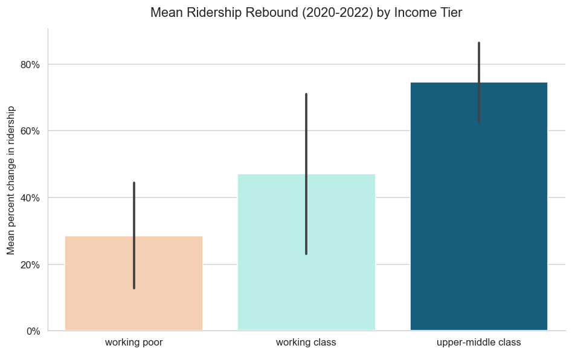

```python
# Summary table
recovery = subway.groupby("income_tier").agg(
    n=("MODZCTA", "count"),
    pct_change_mean=("pct_change_20_22", "mean"),
    pct_change_median=("pct_change_20_22", "median"),
).reindex(TIER_ORDER)

display(recovery.style.format({
    "pct_change_mean":   "{:.1%}",
    "pct_change_median": "{:.1%}",
}))

# Bar chart
fig, ax = plt.subplots(figsize=(8, 5))
sns.barplot(
    data=subway,
    x="income_tier",
    y="pct_change_20_22",
    order=TIER_ORDER,
    palette=PALETTE,
    hue="income_tier",
    legend=False,
    estimator="mean",
    errorbar="sd",
    ax=ax,
)
ax.set_title("Mean Ridership Rebound (2020-2022) by Income Tier", fontsize=13, pad=12)
ax.set_ylabel("Mean percent change in ridership", fontsize=10)
ax.set_xlabel("")
ax.yaxis.set_major_formatter(plt.FuncFormatter(lambda y, _: f"{y:.0%}"))
ax.tick_params(axis="x", labelsize=10)
sns.despine()
plt.tight_layout()
plt.show()
```

## Step 5: COVID Death Rate by Income Tier

Does the death rate follow the same gradient? This step examines the distribution citywide, then names the specific neighborhoods that anchor each end of it.

## Step 5.1: Distribution

COVID death rate by income tier. The gradient is consistent: working poor (662 per 100,000), working class (581), upper-middle class (336). Upper-middle class neighborhoods had roughly half the rate of working poor ones.

| income_tier | n | death_rate_mean | death_rate_median | poverty_rate_mean |
| --- | --- | --- | --- | --- |
| working poor | 29 | 662.2 | 606.3 | 30.5% |
| working class | 100 | 581.4 | 533.9 | 13.9% |
| upper-middle class | 48 | 335.8 | 286.2 | 8.1% |

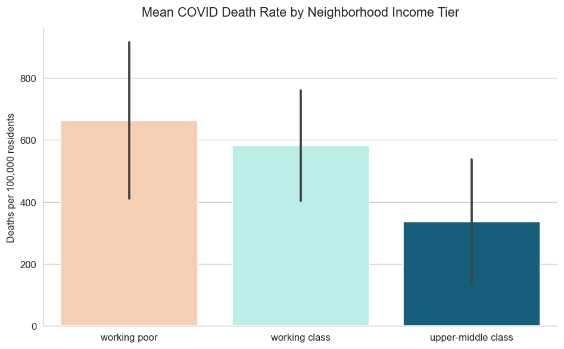

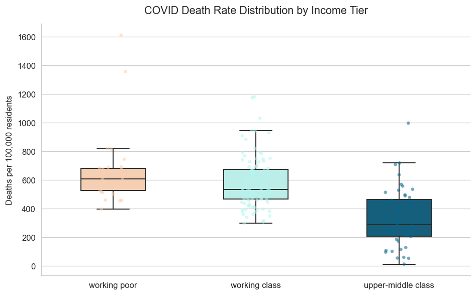

```python
outcomes = gdf.groupby("income_tier").agg(
    n=("MODZCTA", "count"),
    death_rate_mean=("COVID_DEATH_RATE", "mean"),
    death_rate_median=("COVID_DEATH_RATE", "median"),
    poverty_rate_mean=("poverty_rate", "mean"),
).reindex(TIER_ORDER)

display(outcomes.style.format({
    "death_rate_mean":   "{:.1f}",
    "death_rate_median": "{:.1f}",
    "poverty_rate_mean": "{:.1%}",
}))

fig, ax = plt.subplots(figsize=(8, 5))
sns.barplot(
    data=gdf,
    x="income_tier",
    y="COVID_DEATH_RATE",
    order=TIER_ORDER,
    palette=PALETTE,
    hue="income_tier",
    legend=False,
    estimator="mean",
    errorbar="sd",
    ax=ax,
)
ax.set_title("Mean COVID Death Rate by Neighborhood Income Tier", fontsize=13, pad=12)
ax.set_ylabel("Deaths per 100,000 residents", fontsize=10)
ax.set_xlabel("")
ax.tick_params(axis="x", labelsize=10)
sns.despine()
plt.tight_layout()
plt.show()

fig, ax = plt.subplots(figsize=(8, 5))
sns.boxplot(
    data=gdf, x="income_tier", y="COVID_DEATH_RATE",
    order=TIER_ORDER, palette=PALETTE,
    hue="income_tier", legend=False,
    width=0.45, linewidth=1.2, fliersize=0, ax=ax,
)
sns.stripplot(
    data=gdf, x="income_tier", y="COVID_DEATH_RATE",
    order=TIER_ORDER, palette=PALETTE,
    hue="income_tier", legend=False,
    size=4, alpha=0.55, jitter=True, ax=ax,
)
ax.set_title("COVID Death Rate Distribution by Income Tier", fontsize=13, pad=12)
ax.set_ylabel("Deaths per 100,000 residents", fontsize=10)
ax.set_xlabel("")
ax.tick_params(axis="x", labelsize=10)
sns.despine()
plt.tight_layout()
plt.show()
```

## Step 5.2: Outlier Neighborhoods

```python
cols = ["NEIGHBORHOOD_NAME", "MODZCTA", "BOROUGH_GROUP",
        "income_tier", "COVID_DEATH_RATE", "ridership_2020", "pct_change_20_22"]
sorted_gdf = gdf.sort_values("COVID_DEATH_RATE", ascending=False)

print("Top 5 — Highest COVID Death Rate")
display(sorted_gdf[cols].head(5).reset_index(drop=True).style.format({
    "COVID_DEATH_RATE": "{:.1f}",
    "ridership_2020":   "{:,.0f}",
    "pct_change_20_22": "{:.1%}",
}))

print("\nBottom 5 — Lowest COVID Death Rate")
display(sorted_gdf[cols].tail(5).reset_index(drop=True).style.format({
    "COVID_DEATH_RATE": "{:.1f}",
    "ridership_2020":   "{:,.0f}",
    "pct_change_20_22": "{:.1%}",
}))
```

```
Top 5 — Highest COVID Death Rate
```

|  | NEIGHBORHOOD_NAME | MODZCTA | BOROUGH_GROUP | income_tier | COVID_DEATH_RATE | ridership_2020 | pct_change_20_22 |
| --- | --- | --- | --- | --- | --- | --- | --- |
| 0 | East New York | 11239 | Brooklyn | working poor | 1612.6 | nan | nan% |
| 1 | Brighton Beach/Coney Island/Seagate | 11224 | Brooklyn | working poor | 1357.2 | 2,459,218 | 58.7% |
| 2 | Flushing/Murray Hill | 11354 | Queens | working class | 1181.4 | 7,057,461 | 68.2% |
| 3 | Brighton Beach/Manhattan Beach/Sheepshead Bay | 11235 | Brooklyn | working class | 1175.2 | 3,942,206 | 39.9% |
| 4 | Edgemere/Far Rockaway | 11691 | Queens | working class | 1032.1 | 1,219,776 | 15.4% |

```
Bottom 5 — Lowest COVID Death Rate
```

|  | NEIGHBORHOOD_NAME | MODZCTA | BOROUGH_GROUP | income_tier | COVID_DEATH_RATE | ridership_2020 | pct_change_20_22 |
| --- | --- | --- | --- | --- | --- | --- | --- |
| 0 | Lincoln Square | 10069 | Manhattan | upper-middle class | 95.5 | nan | nan% |
| 1 | Financial District | 10006 | Manhattan | upper-middle class | 59.1 | 2,446,574 | 94.8% |
| 2 | Battery Park City | 10282 | Manhattan | upper-middle class | 53.8 | nan | nan% |
| 3 | Long Island City | 11109 | Queens | upper-middle class | 52.1 | nan | nan% |
| 4 | Financial District | 10005 | Manhattan | upper-middle class | 11.4 | 4,460,992 | 54.2% |

## Step 6: Ridership Volume vs COVID Death Rate

This scatterplot includes only MODZCTAs with assigned subway stations. MODZCTAs without assigned stations remain in the COVID death-rate and LISA analysis but are excluded from subway-ridership plots. MODZCTA 11239 (Spring Creek / Starrett City), which has the highest COVID death rate in the dataset, has no assigned subway station and therefore does not appear here.

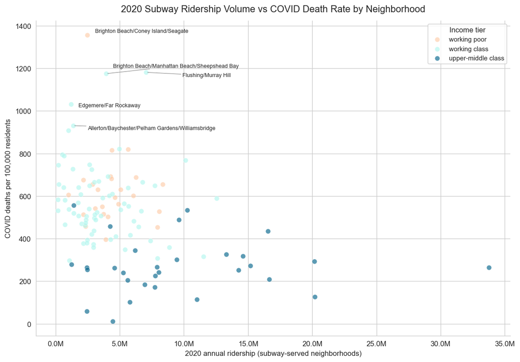

```python
fig, ax = plt.subplots(figsize=(10, 7))

for tier in TIER_ORDER:
    sub = subway[subway["income_tier"] == tier]
    ax.scatter(
        sub["ridership_2020"],
        sub["COVID_DEATH_RATE"],
        c=PALETTE[tier],
        label=tier,
        alpha=0.65,
        s=45,
        edgecolors="white",
        linewidths=0.4,
    )

top_labels = subway.nlargest(5, "COVID_DEATH_RATE")
texts = []
for _, row in top_labels.iterrows():
    texts.append(ax.text(
        row["ridership_2020"], row["COVID_DEATH_RATE"],
        row["NEIGHBORHOOD_NAME"], fontsize=7.5,
    ))
adjust_text(texts, arrowprops=dict(arrowstyle="-", color="grey", lw=0.6))

ax.set_title("2020 Subway Ridership Volume vs COVID Death Rate by Neighborhood", fontsize=13, pad=12)
ax.set_xlabel("2020 annual ridership (subway-served neighborhoods)", fontsize=10)
ax.set_ylabel("COVID deaths per 100,000 residents", fontsize=10)
ax.xaxis.set_major_formatter(plt.FuncFormatter(lambda x, _: f"{x/1e6:.1f}M"))
ax.legend(title="Income tier", fontsize=9)
sns.despine()
plt.tight_layout()
plt.show()
```

## Step 7: The Limits of the Subway Lens

Subway ridership is measured at stations. Fifty-four MODZCTAs have no assigned station under this analysis's spatial join. That absence is not a data error. It is a boundary of the subway-based method, and that boundary matters.

These neighborhoods may rely on buses, ferries, cars, or walking to adjacent MODZCTAs for subway access. Their COVID outcomes belong in the analysis, even when subway ridership cannot be directly attributed to them.

## Step 7.1: Overview by Tier and Borough

The 54 split unevenly across tiers and boroughs. 30 are in Queens, 11 in Staten Island. 18 are upper-middle class, often wealthy areas where residents have cars and choose not to live near a subway. 36 are working class or working poor, areas where bus service can mean 30 to 60 minute trips to the nearest subway connection.

```python
no_station = gdf[gdf["ridership_2020"].isna()].copy()

print(f"Total no-station neighborhoods: {len(no_station)}\n")

print("By income tier:")
display(no_station.groupby("income_tier")["MODZCTA"]
        .count().reindex(TIER_ORDER).rename("count").to_frame())

print("\nBy borough:")
display(no_station.groupby("BOROUGH_GROUP")["MODZCTA"]
        .count().rename("count").to_frame())

print("\nMean COVID death rate (no-station vs subway-served):")
print(f"  No station:     {no_station['COVID_DEATH_RATE'].mean():.1f} per 100K")
print(f"  Subway-served:  {subway['COVID_DEATH_RATE'].mean():.1f} per 100K")
```

```
Total no-station neighborhoods: 54

By income tier:
```

| income_tier | count |
| --- | --- |
| working poor | 5 |
| working class | 31 |
| upper-middle class | 18 |

```
By borough:
```

| BOROUGH_GROUP | count |
| --- | --- |
| Bronx | 5 |
| Brooklyn | 3 |
| Manhattan | 5 |
| Queens | 30 |
| Staten Island | 11 |

```
Mean COVID death rate (no-station vs subway-served):
  No station:     564.5 per 100K
  Subway-served:  512.0 per 100K
```

## Step 7.2: Death Rate Comparison by Income Tier

Within each income tier, no-station neighborhoods compared to subway-served neighborhoods. If no-station working poor neighborhoods carry heavier burden than their subway-served counterparts, that supports the transit-desert interpretation. If the pattern is more uniform within tier, the absence of an assigned station is less consequential than income itself.

| income_tier | access | mean | median | count |
| --- | --- | --- | --- | --- |
| working poor | No station | 815.5 | 674.7 | 5 |
|  | Subway-served | 630.3 | 603.9 | 24 |
| working class | No station | 592.0 | 519.3 | 31 |
|  | Subway-served | 576.6 | 537.1 | 69 |
| upper-middle class | No station | 447.2 | 460.0 | 18 |
|  | Subway-served | 268.9 | 263.7 | 30 |

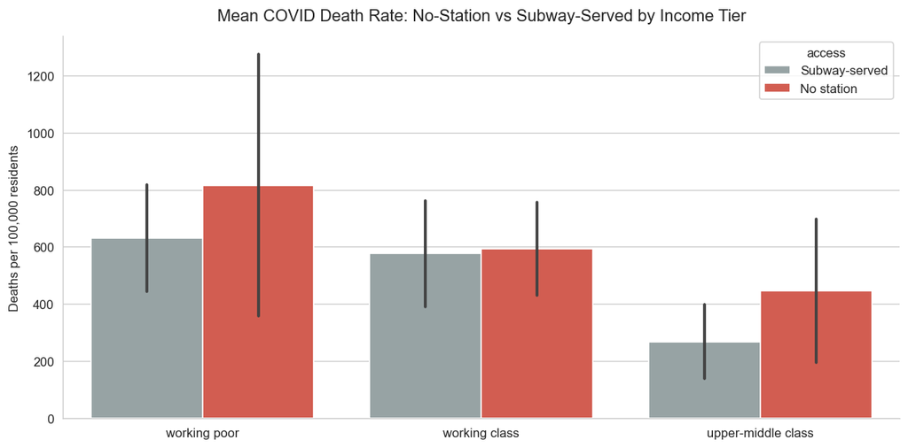

```python
comp = gdf.copy()
comp["access"] = comp["ridership_2020"].isna().map(
    {True: "No station", False: "Subway-served"}
)

comparison = comp.groupby(
    ["income_tier", "access"]
)["COVID_DEATH_RATE"].agg(
    mean="mean", median="median", count="count"
).round(1).reindex(TIER_ORDER, level=0)

display(comparison)

fig, ax = plt.subplots(figsize=(10, 5))
sns.barplot(
    data=comp,
    x="income_tier",
    y="COVID_DEATH_RATE",
    hue="access",
    order=TIER_ORDER,
    palette={"No station": "#e74c3c", "Subway-served": "#95a5a6"},
    estimator="mean",
    errorbar="sd",
    ax=ax,
    legend=True,
)
ax.set_title(
    "Mean COVID Death Rate: No-Station vs Subway-Served by Income Tier",
    fontsize=13, pad=12,
)
ax.set_ylabel("Deaths per 100,000 residents")
ax.set_xlabel("")
ax.tick_params(axis="x", labelsize=10)
sns.despine()
plt.tight_layout()
plt.show()
```

## Step 8: Spatial Autocorrelation

Is the gradient spatially structured, or scattered randomly across the city? If high-death-rate neighborhoods tend to sit next to other high-death-rate neighborhoods, the burden has a geography. This step tests for that pattern citywide and identifies the specific clusters.

## Step 8.1: Spatial Weights

Build the spatial weights matrix using Queen contiguity. Roosevelt Island has no contiguous neighbor and is treated as an island by the algorithm.

```python
from libpysal.weights import Queen
from esda.moran import Moran, Moran_Local
import warnings

w = Queen.from_dataframe(gdf, use_index=True, silence_warnings=True)
w.transform = "r"

islands = [gdf.iloc[i]["NEIGHBORHOOD_NAME"] for i in w.islands]
if islands:
    print(f"NOTE  {len(islands)} island(s) with no contiguous neighbors:")
    for name in islands:
        print(f"      {name}")
else:
    print(f"PASS  No islands. All {len(gdf)} neighborhoods have "
          f"at least one contiguous neighbor.")
```

```
NOTE  1 island(s) with no contiguous neighbors:
      Roosevelt Island
```

## Step 8.2: Global Moran's I

Global Moran's I tests whether the citywide distribution of COVID death rates is clustered or random. A positive significant value means clustered.

```python
y = gdf["COVID_DEATH_RATE"].values
mi = Moran(y, w)

print(f"Global Moran's I")
print(f"  I statistic : {mi.I:.4f}")
print(f"  p-value     : {mi.p_sim:.4f}")
print(f"  z-score     : {mi.z_sim:.4f}")
if mi.p_sim < 0.05:
    direction = "positive" if mi.I > 0 else "negative"
    print(f"  Result      : Statistically significant {direction} "
          f"spatial autocorrelation (p < 0.05).")
    print(f"  Meaning     : High-death-rate neighborhoods cluster "
          f"together. This is not a random distribution.")
```

```
Global Moran's I
  I statistic : 0.4599
  p-value     : 0.0010
  z-score     : 8.6098
  Result      : Statistically significant positive spatial autocorrelation (p < 0.05).
  Meaning     : High-death-rate neighborhoods cluster together. This is not a random distribution.
```

## Step 8.3: Local Clusters (LISA)

Local Moran's I identifies which specific neighborhoods belong to which cluster type. High-High zones are the burden concentrations.

```python
LISA_LABELS = {1: "High-High", 2: "Low-High", 3: "Low-Low", 4: "High-Low"}
with warnings.catch_warnings():
    warnings.simplefilter("ignore", RuntimeWarning)
    lisa = Moran_Local(y, w, seed=42)

sig = lisa.p_sim < 0.05
cluster_type = []
for i in range(len(gdf)):
    if sig[i]:
        cluster_type.append(LISA_LABELS[lisa.q[i]])
    else:
        cluster_type.append("Not Significant")

gdf["lisa_type"] = cluster_type

counts = gdf["lisa_type"].value_counts()
print("LISA cluster type counts:")
display(counts.rename("neighborhoods").to_frame())

display(gdf[gdf["lisa_type"] == "High-High"][
    ["MODZCTA", "NEIGHBORHOOD_NAME", "BOROUGH_GROUP",
     "income_tier", "COVID_DEATH_RATE"]
].sort_values("COVID_DEATH_RATE", ascending=False).reset_index(drop=True))
```

```
LISA cluster type counts:
```

| lisa_type | neighborhoods |
| --- | --- |
| Not Significant | 135 |
| Low-Low | 25 |
| High-High | 9 |
| Low-High | 6 |
| High-Low | 2 |

|  | MODZCTA | NEIGHBORHOOD_NAME | BOROUGH_GROUP | income_tier | COVID_DEATH_RATE |
| --- | --- | --- | --- | --- | --- |
| 0 | 11224 | Brighton Beach/Coney Island/Seagate | Brooklyn | working poor | 1357.23 |
| 1 | 11235 | Brighton Beach/Manhattan Beach/Sheepshead Bay | Brooklyn | working class | 1175.23 |
| 2 | 11692 | Arverne/Edgemere | Queens | working class | 789.38 |
| 3 | 11214 | Bath Beach/Bensonhurst/Gravesend | Brooklyn | working class | 691.70 |
| 4 | 10461 | Morris Park/Pelham Bay/Westchester Square | Bronx | working class | 649.72 |
| 5 | 11236 | Canarsie | Brooklyn | working class | 640.46 |
| 6 | 11368 | Corona/North Corona | Queens | working class | 639.67 |
| 7 | 11207 | Cypress Hills/East New York | Brooklyn | working poor | 631.23 |
| 8 | 11208 | Cypress Hills/East New York | Brooklyn | working poor | 593.31 |

```python
lisa_income_table = pd.crosstab(
    gdf["lisa_type"],
    gdf["income_tier"],
    margins=True,
)
display(lisa_income_table)

lisa_income_pct = pd.crosstab(
    gdf["lisa_type"],
    gdf["income_tier"],
    normalize="index",
) * 100
display(lisa_income_pct.round(1))
```

| income_tier lisa_type | upper-middle class | working class | working poor | All |
| --- | --- | --- | --- | --- |
| High-High | 0 | 6 | 3 | 9 |
| High-Low | 1 | 0 | 1 | 2 |
| Low-High | 0 | 6 | 0 | 6 |
| Low-Low | 23 | 2 | 0 | 25 |
| Not Significant | 24 | 86 | 25 | 135 |
| All | 48 | 100 | 29 | 177 |

| income_tier lisa_type | upper-middle class | working class | working poor |
| --- | --- | --- | --- |
| High-High | 0.0 | 66.7 | 33.3 |
| High-Low | 50.0 | 0.0 | 50.0 |
| Low-High | 0.0 | 100.0 | 0.0 |
| Low-Low | 92.0 | 8.0 | 0.0 |
| Not Significant | 17.8 | 63.7 | 18.5 |

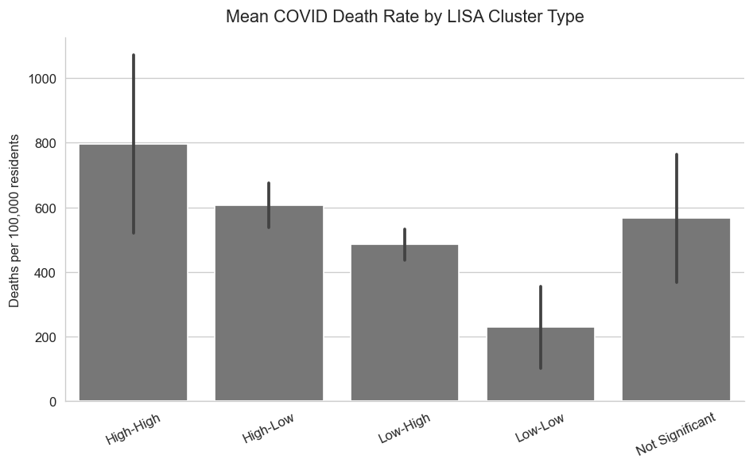

```python
fig, ax = plt.subplots(figsize=(8, 5))

sns.barplot(
    data=gdf,
    x="lisa_type",
    y="COVID_DEATH_RATE",
    order=["High-High", "High-Low", "Low-High", "Low-Low", "Not Significant"],
    estimator="mean",
    errorbar="sd",
    color="#777777",
    ax=ax,
)

ax.set_title("Mean COVID Death Rate by LISA Cluster Type", fontsize=13, pad=12)
ax.set_ylabel("Deaths per 100,000 residents", fontsize=10)
ax.set_xlabel("")
ax.tick_params(axis="x", rotation=25)
sns.despine()
plt.tight_layout()
plt.show()
```

Error bars show standard deviation, representing within-group variation rather than uncertainty around the mean.

## Step 8.4: LISA Cluster Map

The static map view of LISA clusters. Five colors, clear legend, no other variables overlaid. The interactive map in Step 9 integrates this with everything else.

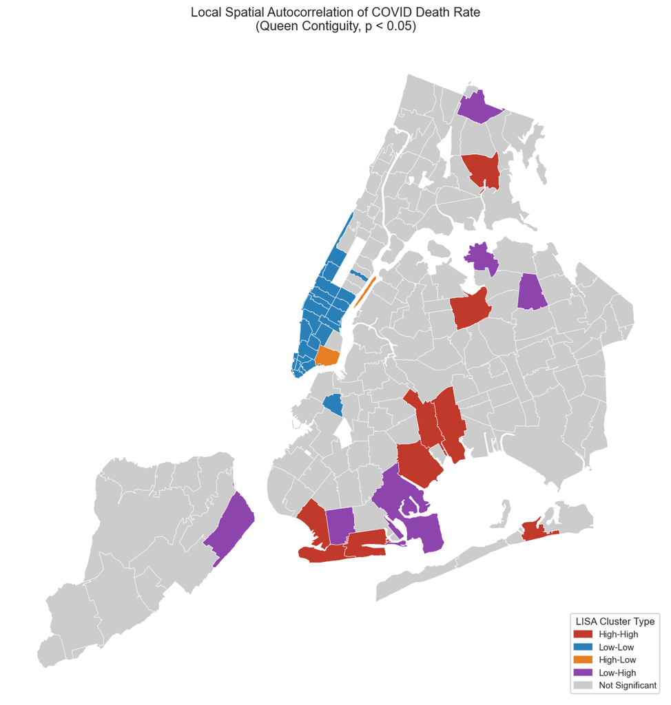

```python
gdf_map_lisa = gdf.to_crs(epsg=4326).copy()
gdf_map_lisa["color"] = gdf_map_lisa["lisa_type"].map(LISA_COLORS)

fig, ax = plt.subplots(figsize=(12, 10))
gdf_map_lisa.plot(
    ax=ax,
    color=gdf_map_lisa["color"],
    edgecolor="white",
    linewidth=0.4,
)

legend_patches = [
    mpatches.Patch(color=LISA_COLORS[k], label=k)
    for k in ["High-High", "Low-Low", "High-Low",
              "Low-High", "Not Significant"]
]
ax.legend(
    handles=legend_patches,
    loc="lower right",
    fontsize=9,
    title="LISA Cluster Type",
    title_fontsize=10,
    framealpha=0.9,
)
ax.set_title(
    "Local Spatial Autocorrelation of COVID Death Rate\n"
    "(Queen Contiguity, p < 0.05)",
    fontsize=13, pad=14,
)
ax.set_axis_off()
plt.tight_layout()
plt.show()
```

## Step 9: Interactive Map

The integrated view. Every neighborhood, every variable, every layer. Income tier as primary color. Subway lines and stations toggleable. LISA cluster type and full data in hover popups.

## Step 9.1: Display Column Preparation

Format the data for human reading: dollar signs, percentages, station name aggregations, plain-language LISA labels.

```python
LISA_DISPLAY = {
    "High-High":       "High burden zone",
    "Low-Low":         "Low burden zone",
    "High-Low":        "Outlier (high in low-burden area)",
    "Low-High":        "Outlier (low in high-burden area)",
    "Not Significant": "No significant clustering",
}

gdf_map = gdf.copy()
gdf_map["lisa_display"] = gdf_map["lisa_type"].map(LISA_DISPLAY)

gdf_map["median_income_display"] = gdf_map["median_income_wtd"].apply(
    lambda x: "N/A" if pd.isna(x) else f"${x:,.0f}"
)
gdf_map["covid_death_rate_display"] = gdf_map["COVID_DEATH_RATE"].apply(
    lambda x: "N/A" if pd.isna(x) else f"{x:,.1f}"
)
gdf_map["ridership_2020_display"] = gdf_map["ridership_2020"].apply(
    lambda x: "No assigned station" if pd.isna(x) else f"{x:,.0f}"
)
gdf_map["pct_change_display"] = gdf_map["pct_change_20_22"].apply(
    lambda x: "N/A" if pd.isna(x) else f"{x * 100:.1f}%"
)
gdf_map["poverty_rate_display"] = gdf_map["poverty_rate"].apply(
    lambda x: "N/A" if pd.isna(x) else f"{x * 100:.1f}%"
)

stations_df = pd.read_csv(os.path.join(DATA_DIR, "stations_with_modzcta.csv"))
stations_agg = (
    stations_df.groupby("MODZCTA")["station_complex"]
    .apply(lambda names: ", ".join(sorted(set(names))))
    .reset_index()
    .rename(columns={"station_complex": "stations"})
)
stations_agg["MODZCTA"] = stations_agg["MODZCTA"].astype(int)
gdf_map["MODZCTA_int"] = gdf_map["MODZCTA"].astype(int)
gdf_map = gdf_map.merge(stations_agg, left_on="MODZCTA_int", right_on="MODZCTA", how="left")
gdf_map["stations"] = gdf_map["stations"].fillna("No assigned station")
gdf_map = gdf_map.drop(columns=["MODZCTA_int", "MODZCTA_y"], errors="ignore")
if "MODZCTA_x" in gdf_map.columns:
    gdf_map = gdf_map.rename(columns={"MODZCTA_x": "MODZCTA"})
```

## Step 9.2: Choropleth Layer

The choropleth itself: income tier as fill color, full data in the popup.

```python
gdf_map_wgs = gdf_map.to_crs(epsg=4326).copy()
gdf_map_wgs["color"] = gdf_map_wgs["income_tier"].map(PALETTE).fillna("#aaaaaa")

fig = folium.Figure(width="100%", height=750)
m = folium.Map(
    location=[40.7128, -74.0060],
    zoom_start=11,
    tiles="CartoDB positron",
).add_to(fig)

def style_fn(feature):
    return {
        "fillColor":   feature["properties"]["color"],
        "color":       "white",
        "weight":      0.6,
        "fillOpacity": 0.72,
    }

def highlight_fn(feature):
    return {
        "fillColor":   feature["properties"]["color"],
        "color":       "#333333",
        "weight":      2.5,
        "fillOpacity": 0.88,
    }

tooltip = GeoJsonTooltip(
    fields=[
        "NEIGHBORHOOD_NAME", "MODZCTA", "BOROUGH_GROUP",
        "income_tier", "median_income_display",
        "covid_death_rate_display", "ridership_2020_display",
        "pct_change_display", "poverty_rate_display",
        "lisa_display", "stations",
    ],
    aliases=[
        "Neighborhood", "MODZCTA", "Borough",
        "Income tier", "Median income",
        "COVID deaths / 100K", "2020 ridership",
        "Ridership rebound 2020-22", "Poverty rate",
        "LISA cluster", "Subway stations",
    ],
    localize=False,
    sticky=True,
    style="""
        background-color: rgba(255, 255, 255, 0.9);
        border: 1px solid #999;
        border-radius: 4px;
        box-shadow: 3px 3px 6px rgba(0,0,0,0.25);
        font-size: 13px;
        max-width: 420px;
        white-space: normal;
    """,
)

folium.GeoJson(
    gdf_map_wgs.__geo_interface__,
    style_function=style_fn,
    highlight_function=highlight_fn,
    tooltip=tooltip,
    name="Neighborhoods",
).add_to(m)
```

```
<folium.features.GeoJson at 0x136e69e50>
```

## Step 9.3: Transit Layers

Subway stations as point markers, subway lines as colored polylines using MTA's official colors. Both toggleable.

```python
subway_lines = gpd.read_file(
    "https://data.ny.gov/resource/s692-irgq.geojson?$limit=50000"
)
print(f"PASS  Subway lines loaded: {len(subway_lines)} features.")

lines_fg = folium.FeatureGroup(name="Subway lines", show=True)
for _, row in subway_lines.iterrows():
    color = LINE_COLORS.get(str(row["service"]).strip().upper(), "#555555")
    folium.GeoJson(
        row["geometry"].__geo_interface__,
        style_function=lambda f, c=color: {
            "color":   c,
            "weight":  3,
            "opacity": 0.8,
        },
        highlight_function=lambda f, c=color: {
            "color":   c,
            "weight":  5,
            "opacity": 1.0,
        },
        tooltip=row["service_name"],
    ).add_to(lines_fg)
lines_fg.add_to(m)

stations_fg = folium.FeatureGroup(name="Subway stations", show=True)
for _, row in stations_df.iterrows():
    folium.CircleMarker(
        location=[row["latitude"], row["longitude"]],
        radius=6,
        color="#333333",
        fill=True,
        fill_color="#ffffff",
        fill_opacity=0.9,
        weight=1.5,
        tooltip=row["station_complex"],
    ).add_to(stations_fg)
stations_fg.add_to(m)
```

```
PASS  Subway lines loaded: 29 features.
```

```
<folium.map.FeatureGroup at 0x13647fee0>
```

## Step 9.4: Output

Legend, layer control, save to map.html. The output renders in any modern browser.

```python
legend_html = (
    "<div style=\"position:fixed; bottom:30px; left:30px; z-index:1000;\n"
    "            background:white; padding:12px 16px; border-radius:6px;\n"
    "            box-shadow:0 2px 6px rgba(0,0,0,0.3); font-family:sans-serif;\n"
    "            font-size:13px; line-height:1.8;\">\n"
    "  <b>Income Tier</b><br>\n"
    "  <span style=\"background:#FECDAA;width:14px;height:14px;"
    "        display:inline-block;border-radius:2px;margin-right:6px;\"></span>Working poor<br>\n"
    "  <span style=\"background:#B2F7EF;width:14px;height:14px;"
    "        display:inline-block;border-radius:2px;margin-right:6px;\"></span>Working class<br>\n"
    "  <span style=\"background:#05668D;width:14px;height:14px;"
    "        display:inline-block;border-radius:2px;margin-right:6px;\"></span>Upper-middle class<br>\n"
    "  <span style=\"background:#aaaaaa;width:14px;height:14px;"
    "        display:inline-block;border-radius:2px;margin-right:6px;\"></span>No data\n"
    "</div>"
)
m.get_root().html.add_child(folium.Element(legend_html))

map_var = f"map_{m._id}"
hover_effects = folium.Element(f"""
<style>
  /* Glow on subway line SVG paths on hover */
  .leaflet-interactive:hover {{
    filter: drop-shadow(0 0 5px currentColor);
  }}
</style>
<script>
  document.addEventListener('DOMContentLoaded', function() {{
    setTimeout(function() {{
      var theMap = window['{map_var}'];

      function wireCircles(layer) {{
        if (typeof layer.eachLayer === 'function') {{
          layer.eachLayer(wireCircles);
        }}
        if (layer instanceof L.CircleMarker) {{
          var origFill   = layer.options.fillColor;
          var origRadius = layer.options.radius;
          layer.on('mouseover', function() {{
            this.setStyle({{ fillColor: '#B6D7B9' }});
            this.setRadius(origRadius * 1.5);
            if (this._path) {{
              this._path.style.filter = 'drop-shadow(0 0 8px rgba(5,102,141,0.85))';
            }}
          }});
          layer.on('mouseout', function() {{
            this.setStyle({{ fillColor: origFill }});
            this.setRadius(origRadius);
            if (this._path) {{
              this._path.style.filter = '';
            }}
          }});
        }}
      }}

      theMap.eachLayer(wireCircles);
    }}, 1500);
  }});
</script>
""")
m.get_root().html.add_child(hover_effects)
folium.LayerControl(collapsed=False).add_to(m)
m.save(MAP_PATH)
print(f"Map saved to {MAP_PATH}")
fig
```

```
Map saved to map.html
```

[interactive chart not shown]

## Step 10: What the Data Showed for Three Kinds of Neighborhood

**Working poor outer-borough neighborhoods.** Brighton Beach / Coney Island / Seagate (MODZCTA 11224) anchors the High-High LISA cluster, a working poor Brooklyn neighborhood with a significant elderly immigrant population. COVID death rate: 1,357 per 100,000, second only to Spring Creek / Starrett City (11239) at 1,612. Eight other High-High clusters sit in Brooklyn, Queens, and the Bronx, all working class or working poor. The pattern the expectations described is the pattern the data showed. The high-burden geography exists, and it is concentrated.

**Convergence with professional retrospectives.** The NYS Comptroller's archived subway recovery tracker found ridership through early 2022 remained higher in lower-income neighborhoods. The NYC Comptroller's "Riders Return" report identified the Bronx as leading recovery at 52% of 2019 levels in 2021. The "Beyond Rush Hour" report states that the system "will increasingly serve lower-income New Yorkers." This analysis arrives at the same conclusions from neighborhood-level MODZCTA data rather than borough-level aggregates. Independent convergence from different vantage points.

## Step 11: Policy Implications

The analysis is descriptive, but the implications may not be.

The MTA suspended overnight subway service on May 6, 2020, to allow for cleaning. The cleaning rationale is documented. The distributional impact is a separate question, and this analysis helps surface it. Essential workers in working poor neighborhoods were among the people most likely to keep riding through the worst of 2020, and they were also among the people most affected by the loss of overnight service.

Remote work, unlimited PTO, and the ability to stop riding the subway are not evenly distributed in this city. More than 70% of New York's essential workers are people of color, according to NYC Comptroller analysis. Unlimited PTO and remote work are not neutral employment benefits. In practice, they operate as racialized and classed protections, available to populations the death-rate gradient in this analysis shows were the most protected.

The farebox recovery model assumes ridership loss is temporary and commuters return. Working poor neighborhoods rebounded at 28.5% through 2022. Upper-middle class neighborhoods rebounded at 74.5%. If service investment decisions are calibrated to where ridership returned fastest, they will structurally underinvest in the neighborhoods that never left. A system built around commuter recovery can miss the riders who never fully left.

The 9 High-High LISA clusters are all in Brooklyn, Queens, and the Bronx -- all working class or working poor. According to this analysis, spatial concentration of burden was not random, it mapped onto the geography of essential work and transit dependence. Service decisions that do not account for that geography are decisions that will continue to fall non-neutrally.

## Step 12: 2026

### The Pattern Continues

This analysis ends in 2022. The question it asks does not.

The G train is running under "a generation of neglect", MTA CEO Janno Lieber's words, on the record in 2026. The Newtown Creek tunnel requires far more work than originally projected. The J has recurring weekend suspensions from Crescent Street to Jamaica Center. The L cuts service between Lorimer and Broadway Junction on weeknights and weekends. These three lines run through Bushwick, East New York, Greenpoint, and the working class outer-borough neighborhoods this analysis identifies as having carried the highest burden in 2020.

This section does not claim that the same policy choices caused both the pandemic burden and later service disruptions, it shows that the affected geographies overlap in ways worth tracking.

The lack of train access tends to compound existing inequality. Residents with cars can reach distant neighborhoods reliably. Everyone else depends on bus service at the whims of traffic congestion and reduced schedules. College Point in northeastern Queens is one example: working class, dense, and 30 to 60 minutes from the nearest subway connection by bus. The Interborough Express (LBX) has been proposed for years to connect Brooklyn and Queens without routing through Manhattan. As of 2026 it has not been built.

The 9 High-High LISA cluster neighborhoods are not abstract. They are places where the infrastructure now failing most visibly is the same infrastructure that essential workers depended on during the worst of the pandemic. Whether that pattern is coincidental is a question this data alone cannot answer. The geography is the same.

Deferred maintenance is not a technical problem. It is a record of whose infrastructure was prioritized and whose was promised later. The data from 2020 to 2022 shows who kept the city running. The service schedule in 2026 shows what they got for it.

### Main Takeaway

The maps and charts show a consistent geography of unequal burden. Working poor and working class neighborhoods had higher COVID death rates, and many of those same areas were tied to subway access patterns that reveal uneven mobility options.

This analysis does not prove that subway dependence caused COVID deaths. It shows that income, transit dependence, and public health burden overlapped geographically in ways that matter for future service planning, emergency response, and infrastructure investment.

## Step 13: Data Notes and Limitations

This analysis is a scoped prototype: one snapshot of one shock, described at neighborhood resolution. The notes below are methodological choices and known boundaries. Each is documented so the data can be extended, revisited, or contested intentionally.

**MODZCTA is the analytical unit, not neighborhood.** Neighborhood names in the COVID dataset are descriptive labels. Multiple MODZCTAs share names (Financial District, Battery Park City, Lincoln Square). All grouping and analysis is by MODZCTA. Names are kept only for human readability.

**Income tier thresholds are fixed methodological choices.** The cutoffs at $50,000 and $100,000 reflect real material differences in NYC cost of living, but they are still choices. Different thresholds would produce different tier assignments. Neutrality is not neutral: classification choices shape what the analysis can see, what it hides, and which populations become legible in the final maps.

**ACS 2021 vintage applied to 2020 deaths.** The income data is one year newer than the mortality data. Neighborhood demographics in early 2020 may have differed slightly. Median household income is also top-coded at $250,001 by Census design, which compresses the upper tier.

**Subway ridership is measured at station location, not residence.** A station counted toward a MODZCTA's ridership serves commuters from many MODZCTAs. The death rate is counted at residence. These are different geographies and should be read that way.

**54 MODZCTAs have no assigned station.** Bus, ferry, and walking access to adjacent stations exist. The spatial join in Part 1 attributes subway ridership only to MODZCTAs containing stations. These 54 stay in every other analysis and surface in Step 7 as their own finding.

**Annual ridership absorbs the 2020 overnight suspension.** The May-June 2020 service cut is baked into ridership_2020 and cannot be separated within this annual aggregation.

**Rebound, not recovery.** pct_change_20_22 measures climb from the 2020 floor to 2022 levels. A true recovery metric would require 2019 baseline data, which this version does not include. The longitudinal extension will.

**LISA threshold at p < 0.05, unadjusted.** Standard exploratory practice. Cluster assignments are hypothesis-generating, not confirmatory.

**Roosevelt Island has no Queen-contiguous neighbor.** It sits in the East River with water polygons as its surround. Queen contiguity excludes it from the spatial weights matrix.

**MODZCTA 11239 (Spring Creek / Starrett City) is outside the High-High LISA cluster despite the highest death rate in the dataset.** Its southeastern edge position near Jamaica Bay limits its contiguous neighbors. The spatial method underrepresents its burden here. The neighborhood appears prominently in the outlier table in Step 5.2 instead, where it cannot be missed.

**Descriptive, not causal.** The analysis identifies spatial clustering, income gradients, and ridership patterns. It does not prove that any one of these caused the others. The causal version requires controls and finer-grained data a longitudinal extension is designed to support.

This snapshot is the foundation. A longitudinal extension of the project layers on more years (pre-pandemic baselines, multiple shock periods, future events), additional transit modes (bus, ferry, LIRR), policy cycles, labor market indicators, and a regressor that can model neighborhood trajectories over time rather than at a single point. The 2026 disruption pattern in Step 12 is one example of the kind of pattern a longitudinal version would track across shocks rather than describe after one.

## References

### Data Sources Used in Analysis

- [NYC Department of Health and Mental Hygiene. COVID-19 Data Repository.](https://github.com/nychealth/coronavirus-data)  
  Source for NYC COVID-19 data, including MODZCTA-level cumulative cases, deaths, and rates.
- [NYC DOHMH. MODZCTA COVID-19 data: `data-by-modzcta.csv`.](https://github.com/nychealth/coronavirus-data/blob/master/totals/data-by-modzcta.csv)  
  Direct CSV used for MODZCTA-level COVID outcomes.
- [NYC DOHMH. Modified ZIP Code Tabulation Areas explanation.](https://nychealth.github.io/covid-maps/modzcta-geo/about.html)  
  Background on MODZCTA geography and why NYC Health uses it for neighborhood-level health reporting.
- [NYC Open Data. Modified Zip Code Tabulation Areas (MODZCTA).](https://data.cityofnewyork.us/Health/Modified-Zip-Code-Tabulation-Areas-MODZCTA-/pri4-ifjk)  
  MODZCTA boundary geography used for mapping.
- [NYC Environmental Health. NYC Geography GitHub Repository.](https://github.com/nycehs/NYC_geography)  
  Reference repository for NYC geographic boundary files, including simplified GeoJSON and shapefile resources.
- [MTA / State of New York Open Data. MTA Subway Hourly Ridership: 2020-2024.](https://data.ny.gov/Transportation/MTA-Subway-Hourly-Ridership-2020-2024/wujg-7c2s)  
  Source for station-level subway ridership used to calculate 2020 ridership volume and 2020-2022 rebound.
- [MTA / State of New York Open Data. MTA Subway Stations.](https://data.ny.gov/Transportation/MTA-Subway-Stations/39hk-dx4f)  
  Source for subway station locations used in the spatial join to MODZCTAs.
- [MTA / State of New York Open Data. MTA Subway Service Lines.](https://data.ny.gov/Transportation/MTA-Subway-Service-Lines/s692-irgq)  
  Source for subway line geometries used in the interactive map.
- [U.S. Census Bureau. ACS 2021 5-Year Estimates, Selected Economic Characteristics, DP03.](https://data.census.gov/table/ACSDP5Y2021.DP03)  
  Source for median household income and related neighborhood economic variables.
- [U.S. Census Bureau. Census Data API: 2021 ACS 5-Year Profile Variables.](https://api.census.gov/data/2021/acs/acs5/profile/variables.html)  
  API documentation used to retrieve ACS 2021 variables.
- `data/stations_with_modzcta.csv`  
  Intermediate file built in Part 1 of this project. Used to connect subway stations to MODZCTAs.

### External Validation and Context

- [New York State Comptroller. Archived Subway Recovery Tracker.](https://www.osc.ny.gov/reports/osdc/subway-recovery-tracker-archived)  
  Context for post-2020 subway ridership patterns and recovery differences across the city.
- [New York State Comptroller. Subway Recovery Tracker.](https://www.osc.ny.gov/osdc/subway-recovery-tracker)  
  Current version of the subway recovery tracker.
- [New York City Comptroller. Beyond Rush Hour.](https://comptroller.nyc.gov/reports/beyond-rush-hour/)  
  Context on changing commute patterns, off-peak transit use, and lower-income riders.
- [New York City Comptroller. Riders Return.](https://comptroller.nyc.gov/reports/riders-return/)  
  Context on subway and bus ridership recovery after the first years of the pandemic.
- [New York City Comptroller. New York City’s Frontline Workers.](https://comptroller.nyc.gov/reports/new-york-citys-frontline-workers/)  
  Source for demographic and labor context on frontline workers during COVID-19.
- [New York City Comptroller. Comptroller Stringer Releases New Data Profiles of Frontline Workers and Calls for Protections Amid COVID-19 Pandemic.](https://comptroller.nyc.gov/newsroom/comptroller-stringer-releases-new-data-profiles-of-frontline-workers-and-calls-for-protections-amid-covid-19-pandemic/)  
  Additional context on the scale and composition of NYC’s frontline workforce.
- [Bilal et al. Spatial Inequities in COVID-19 Testing, Positivity, Confirmed Cases, and Mortality in 3 U.S. Cities. Annals of Internal Medicine, 2021.](https://pmc.ncbi.nlm.nih.gov/articles/PMC8029592/)  
  Scholarly context for spatial inequities in COVID-19 outcomes across New York City, Philadelphia, and Chicago.
- [Zhong et al. Neighborhood disparities in COVID-19 outcomes in New York City. Journal of Urban Health, 2022.](https://pmc.ncbi.nlm.nih.gov/articles/PMC9042413/)  
  Scholarly context on MODZCTA-level neighborhood disparities in NYC COVID-19 outcomes.

### News and Current Reporting

- [MTA. Annual Disclosure Statement Update, November 24, 2020.](https://www.mta.info/document/24571)  
  MTA disclosure document covering COVID-era operating conditions and service changes.
- [Queens Daily Eagle. MTA suspends overnight subway service indefinitely.](https://queenseagle.com/all/mta-suspends-overnight-subway-service)  
  Reporting on the May 2020 overnight subway suspension.
- [ABC7NY. G train service disruptions get underway for subway riders.](https://abc7ny.com/post/train-service-disruptions-get-underway-subway-riders-brooklyn-queens/18987619/)  
  Reporting on recurring 2026 G train service changes, including track work and signal modernization affecting Brooklyn and Queens.
- [MTA. Service changes on the G line in 2026.](https://www.mta.info/article/service-changes-g-line-2026)  
  Official MTA notice for recurring G train service changes in 2026.
- [MTA. MTA Weekender: April 17-20, 2026.](https://www.mta.info/article/mta-weekender-april-17-20-2026)  
  Official MTA service-change notice documenting G train suspensions between Court Sq and Bedford-Nostrand Avs for signal modernization, and J train suspensions between Jamaica Center-Parsons/Archer and Crescent St for track replacement.
- [MTA. MTA Weekender: April 10-13, 2026.](https://www.mta.info/article/mta-weekender-april-10-13-2026)  
  Official MTA service-change notice documenting J train suspensions between Jamaica Center-Parsons/Archer and Crescent St, with J90 shuttle buses serving stops between 121 St and Crescent St.
- [MTA. MTA Weekender: February 20-23, 2026.](https://www.mta.info/article/mta-weekender-february-20-23-2026)  
  Official MTA service-change notice documenting J and M service changes between Marcy Av and Myrtle Av for structural work.
- [MTA. MTA Weekender: Martin Luther King Jr. Day Weekend 2026.](https://www.mta.info/article/mta-weekender-martin-luther-king-jr-day-weekend-2026)  
  Official MTA service-change notice documenting J train suspensions between Jamaica Center-Parsons/Archer and Crescent St and L train suspensions between Lorimer St and Broadway Junction.
- [MTA. Major service changes on the 4 and 5 lines in January and February 2026.](https://www.mta.info/article/major-service-changes-4-and-5-lines-january-and-february-2026)  
  Official MTA notice documenting 4 and 5 line service changes for switch replacement in January and February 2026.

### Background and Framing

- [New York City Comptroller. The Human Cost of Subway Delays.](https://comptroller.nyc.gov/reports/the-human-cost-of-subway-delays-a-survey-of-new-york-city-riders/)  
  Background on how subway delays affect lower-income New Yorkers.
- [New York City Comptroller. Comptroller Stringer Releases New Report and Survey Results on the Human Impacts of Subway Delays.](https://comptroller.nyc.gov/newsroom/comptroller-stringer-releases-new-report-and-survey-results-on-the-human-impacts-of-subway-delays-on-straphangers-lives/)  
  Related press release summarizing unequal impacts of subway delays.
- [NYC Open Data. Open Data for All New Yorkers.](https://opendata.cityofnewyork.us/)  
  General reference for NYC’s open data infrastructure.